# Introduction to R

Nguyen Bich Ngoc

21 June, 2024

```r
library(formatR)
library(knitr)
knitr::opts_chunk$set(tidy.opts = list(width.cutoff = 60), tidy = TRUE)
```

# Introduction

## R

- Developed from S - interpreted language
- mostly use in statistics and data analysis
- free & open-source
- extendable with packages and new functions
- https://cran.r-project.org/

## RStudio

- Interface
- only work with R installed
- free & open-source
- start and save scripts
- Ctrl+Enter to run
- http://rstudio.com/

## Let’s start with some simple calculations

```r
2 + 3
```

```
## [1] 5
```

```r
4^2
```

```
## [1] 16
```

```r
sqrt(25)
```

```
## [1] 5
```

```r
8^(1/3)
```

```
## [1] 2
```

```r
pi
```

```
## [1] 3.141593
```

```r
exp(1)
```

```
## [1] 2.718282
```

```r
log(exp(2))
```

```
## [1] 2
```

```r
log10(100)
```

```
## [1] 2
```

## Packages & Functions

- packages add additional functions
- packages need to be installed once
- sometime will need to be installed again after update
- load before every run

```r
# install.packages('ggplot2')
library(ggplot2)
```

- functions receive arguments => return results

```r
rnorm(100, mean = 0, sd = 1)
```

```
##   [1]  1.719448877  1.263746338  0.594446171  0.039956478 -1.497097454
##   [6]  1.312685950 -1.557754510 -0.997433352 -0.488883623  0.360059203
##  [11] -0.176754245  0.176047461  1.955543138  0.880398012 -0.180317583
##  [16] -0.560395071  1.379533772 -0.918207394 -0.574940786 -0.261918698
##  [21]  1.319660470  0.129932594 -0.346294575  2.656513996 -0.127914018
##  [26] -0.728039059  0.732366074 -2.168579390  0.394052668 -0.163904465
##  [31] -0.597356478  0.655211699  0.130930581 -0.200302730 -0.548028523
##  [36] -0.732626111  0.574521072 -0.930290609  1.269643898 -1.133396716
##  [41] -1.386853090 -0.310853021 -0.783421105  0.130813423  0.270833141
##  [46] -0.522248098  0.769793087 -1.508773052 -0.084841794 -1.596032956
##  [51] -0.889447336  0.850453015 -1.943943499 -1.046075622  0.964946596
##  [56]  0.341161598 -0.330916137 -1.904723854 -1.678772361  1.279373540
##  [61] -0.330573524 -0.285847410 -0.556644857  0.641468166 -1.147554871
##  [66]  0.785072195  0.502956040  1.734376407 -0.687047539 -0.060330102
##  [71] -0.836067537 -1.036681927 -0.771125461  0.304145974 -0.515908178
##  [76] -1.003466095  0.137050015 -0.288362229  0.590690640  0.230885878
##  [81]  1.453743001  1.171947616  2.048510340  0.295189440  0.666591192
##  [86] -1.287554736 -0.926909918 -0.619139905 -0.595655118 -0.250632524
##  [91]  2.074204628  0.054745615 -1.932925681  0.839159047  1.064255899
##  [96]  0.307333030 -0.928253902  0.400589658  0.009951168 -0.379929449
```

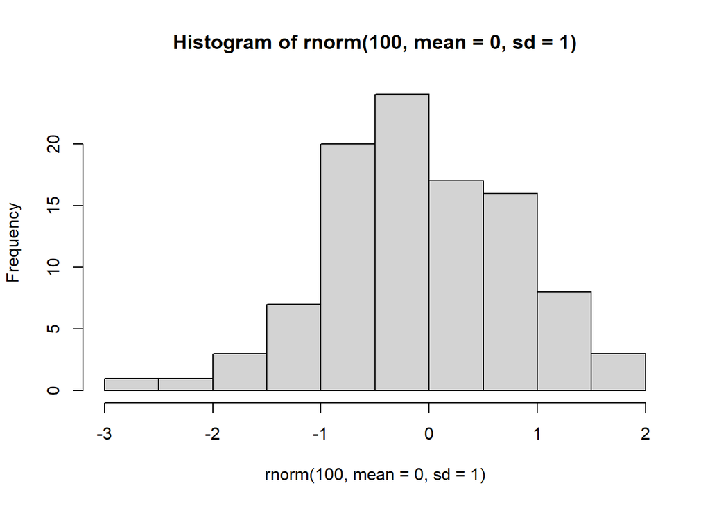

```r
hist(rnorm(100, mean = 0, sd = 1))
```

## Operators

```r
x <- 2 + 3
y = 6 - 5

x == 3
```

```
## [1] FALSE
```

```r
y != 2
```

```
## [1] TRUE
```

```r
x < 0
```

```
## [1] FALSE
```

```r
y < 4
```

```
## [1] TRUE
```

```r
x >= 5
```

```
## [1] TRUE
```

```r
y <= 10
```

```
## [1] TRUE
```

```r
is.na(x)
```

```
## [1] FALSE
```

```r
x < 0 & y < 4
```

```
## [1] FALSE
```

```r
x < 0 | y < 4
```

```
## [1] TRUE
```

## Getting help

```r
`?`(sqrt)
```

```
## starting httpd help server ... done
```

```r
# x + 3
x <- 2
x + 3
```

```
## [1] 5
```

# Data

## Data types

- numeric: e.g. `1`, `45.3`
- integer: e.g. `2L`, `53L`
- logical: e.g. `TRUE`, `T`, `FALSE`, `F`
- character: e.g. `"orange"`, `"female"`, `"Totally agree"`

## Data structure

- Vectors
- Matrix
- Data frame
- List

### Vectors

- simplest type

```r
x <- c(1, 8, 23, -7, 13)
x
```

```
## [1]  1  8 23 -7 13
```

```r
y <- c("a", "b", "c", "d", "e")
y
```

```
## [1] "a" "b" "c" "d" "e"
```

- same type of data

```r
a <- c(1, "a", 3, T)
a
```

```
## [1] "1"    "a"    "3"    "TRUE"
```

```r
str(a)
```

```
##  chr [1:4] "1" "a" "3" "TRUE"
```

```r
str(x)
```

```
##  num [1:5] 1 8 23 -7 13
```

```r
str(y)
```

```
##  chr [1:5] "a" "b" "c" "d" "e"
```

```r
b = c(1L, 8L, 23L, -7L, 13L)
str(b)
```

```
##  int [1:5] 1 8 23 -7 13
```

- creating vector

```r
x <- c(1, 8, 23, -7, 13)
x <- 1:20
y <- seq(from = 3, to = 8, by = 0.2)


rep("Female", 10)
```

```
##  [1] "Female" "Female" "Female" "Female" "Female" "Female" "Female" "Female"
##  [9] "Female" "Female"
```

- Vectorization

```r
x <- c(3, 7, 6, 3, 5, 2)
x + 1
```

```
## [1] 4 8 7 4 6 3
```

```r
x * 2
```

```
## [1]  6 14 12  6 10  4
```

```r
sqrt(x)
```

```
## [1] 1.732051 2.645751 2.449490 1.732051 2.236068 1.414214
```

- logical vector

```r
x
```

```
## [1] 3 7 6 3 5 2
```

```r
z <- x > 4
z
```

```
## [1] FALSE  TRUE  TRUE FALSE  TRUE FALSE
```

```r
y <- c("a", "b", "a", "d", "e")

t <- y == "A"
t
```

```
## [1] FALSE FALSE FALSE FALSE FALSE
```

```r
t <- y == "a"
t
```

```
## [1]  TRUE FALSE  TRUE FALSE FALSE
```

- useful functions for vectors

```r
x
```

```
## [1] 3 7 6 3 5 2
```

```r
length(x)
```

```
## [1] 6
```

```r
sum(x)
```

```
## [1] 26
```

```r
max(x)
```

```
## [1] 7
```

```r
min(x)
```

```
## [1] 2
```

```r
sort(x)
```

```
## [1] 2 3 3 5 6 7
```

```r
order(x)
```

```
## [1] 6 1 4 5 3 2
```

```r
unique(x)
```

```
## [1] 3 7 6 5 2
```

```r
mean(x)
```

```
## [1] 4.333333
```

```r
sd(x)
```

```
## [1] 1.966384
```

```r
y
```

```
## [1] "a" "b" "a" "d" "e"
```

```r
length(y)
```

```
## [1] 5
```

```r
unique(y)
```

```
## [1] "a" "b" "d" "e"
```

- subset vector

```r
x
```

```
## [1] 3 7 6 3 5 2
```

```r
x[1]
```

```
## [1] 3
```

```r
x[3:5]
```

```
## [1] 6 3 5
```

```r
x[c(1, 3:5)]
```

```
## [1] 3 6 3 5
```

```r
x[-2]
```

```
## [1] 3 6 3 5 2
```

```r
x[x > 4]
```

```
## [1] 7 6 5
```

```r
v <- 3
v[1]
```

```
## [1] 3
```

### Matrices

- same type of data
- columns & rows

```r
x <- rbind(c(1:4), c(5:8))
x
```

```
##      [,1] [,2] [,3] [,4]
## [1,]    1    2    3    4
## [2,]    5    6    7    8
```

```r
dim(x)
```

```
## [1] 2 4
```

```r
dimnames(x)
```

```r
attributes(x)
```

```
## $dim
## [1] 2 4
```

```r
x <- cbind(c(1:4), c(5:8))
attributes(x)
```

```
## $dim
## [1] 4 2
```

```r
x <- matrix(1:8, nrow = 2, ncol = 4, byrow = T)
x
```

```
##      [,1] [,2] [,3] [,4]
## [1,]    1    2    3    4
## [2,]    5    6    7    8
```

```r
x <- matrix(1:8, nrow = 2, ncol = 4, byrow = F)
x
```

```
##      [,1] [,2] [,3] [,4]
## [1,]    1    3    5    7
## [2,]    2    4    6    8
```

### Data frame

- extension of matrix
- columns of different data types

```r
id <- 1:6
gender <- rep(c("F", "M"), each = 3)
age <- rep(8, 6)

students <- cbind(id, gender, age)
students
```

```
##      id  gender age
## [1,] "1" "F"    "8"
## [2,] "2" "F"    "8"
## [3,] "3" "F"    "8"
## [4,] "4" "M"    "8"
## [5,] "5" "M"    "8"
## [6,] "6" "M"    "8"
```

```r
str(students)
```

```
##  chr [1:6, 1:3] "1" "2" "3" "4" "5" "6" "F" "F" "F" "M" "M" "M" "8" "8" "8" ...
##  - attr(*, "dimnames")=List of 2
##   ..$ : NULL
##   ..$ : chr [1:3] "id" "gender" "age"
```

```r
summary(students)
```

```
##       id               gender              age
##  Length:6           Length:6           Length:6
##  Class :character   Class :character   Class :character
##  Mode  :character   Mode  :character   Mode  :character
```

```r
students <- cbind.data.frame(id, gender, age)
students
```

| id | gender | age |
| --- | --- | --- |
| 1 | F | 8 |
| 2 | F | 8 |
| 3 | F | 8 |
| 4 | M | 8 |
| 5 | M | 8 |
| 6 | M | 8 |

```r
str(students)
```

```
## 'data.frame':    6 obs. of  3 variables:
##  $ id    : int  1 2 3 4 5 6
##  $ gender: chr  "F" "F" "F" "M" ...
##  $ age   : num  8 8 8 8 8 8
```

```r
summary(students)
```

```
##        id          gender               age
##  Min.   :1.00   Length:6           Min.   :8
##  1st Qu.:2.25   Class :character   1st Qu.:8
##  Median :3.50   Mode  :character   Median :8
##  Mean   :3.50                      Mean   :8
##  3rd Qu.:4.75                      3rd Qu.:8
##  Max.   :6.00                      Max.   :8
```

```r
id <- 1:6
math <- c(9, 6, 7, 8, 10, 5)
english <- c(8, 5, 9, 8, 9, 7)

results <- cbind.data.frame(id, math, english)

df <- merge(students, results)
df
```

| id | gender | age | math | english |
| --- | --- | --- | --- | --- |
| 1 | F | 8 | 9 | 8 |
| 2 | F | 8 | 6 | 5 |
| 3 | F | 8 | 7 | 9 |
| 4 | M | 8 | 8 | 8 |
| 5 | M | 8 | 10 | 9 |
| 6 | M | 8 | 5 | 7 |

- subset data frame

```r
sub1 <- df[1:3, 1:2]
sub1
```

|  | id | gender |
| --- | --- | --- |
| 1 | 1 | F |
| 2 | 2 | F |
| 3 | 3 | F |

```r
sub2 <- df[, c(1, 4:5)]
sub2
```

| id | math | english |
| --- | --- | --- |
| 1 | 9 | 8 |
| 2 | 6 | 5 |
| 3 | 7 | 9 |
| 4 | 8 | 8 |
| 5 | 10 | 9 |
| 6 | 5 | 7 |

```r
sub3 <- df$gender
sub3
```

```
## [1] "F" "F" "F" "M" "M" "M"
```

```r
sub4 <- subset(df, math > 7, select = c(id, english))
sub4
```

|  | id | english |
| --- | --- | --- |
| 1 | 1 | 8 |
| 4 | 4 | 8 |
| 5 | 5 | 9 |

```r
sub5 <- subset(df, english <= 7, select = -age)
sub5
```

|  | id | gender | math | english |
| --- | --- | --- | --- | --- |
| 2 | 2 | F | 6 | 5 |
| 6 | 6 | M | 5 | 7 |

- reorder the data frame

```r
df1 <- df[order(df$math), ]
df1
```

|  | id | gender | age | math | english |
| --- | --- | --- | --- | --- | --- |
| 6 | 6 | M | 8 | 5 | 7 |
| 2 | 2 | F | 8 | 6 | 5 |
| 3 | 3 | F | 8 | 7 | 9 |
| 4 | 4 | M | 8 | 8 | 8 |
| 1 | 1 | F | 8 | 9 | 8 |
| 5 | 5 | M | 8 | 10 | 9 |

### List

- contain different type of data
- can contain data frame

```r
cls1 <- data.frame(id = 1:5, names = c("Lan", "Hung", "Tuan",
    "Mai", "Long"))
cls2 <- data.frame(id = 6:10, names = c("Thanh", "Son", "Nghia",
    "Hanh", "Thuy"))

ls <- list(cls1 = cls1, cls2 = cls2)
ls
```

```
## $cls1
##   id names
## 1  1   Lan
## 2  2  Hung
## 3  3  Tuan
## 4  4   Mai
## 5  5  Long
##
## $cls2
##   id names
## 1  6 Thanh
## 2  7   Son
## 3  8 Nghia
## 4  9  Hanh
## 5 10  Thuy
```

- subset list

```r
ls[1]
```

```
## $cls1
##   id names
## 1  1   Lan
## 2  2  Hung
## 3  3  Tuan
## 4  4   Mai
## 5  5  Long
```

```r
ls[[1]]
```

| id | names |
| --- | --- |
| 1 | Lan |
| 2 | Hung |
| 3 | Tuan |
| 4 | Mai |
| 5 | Long |

```r
ls$cls1
```

| id | names |
| --- | --- |
| 1 | Lan |
| 2 | Hung |
| 3 | Tuan |
| 4 | Mai |
| 5 | Long |

## Import data

- Direct typing
- From clipboard

```r
# open excel file 'C:\Users\nbngo\OneDrive\Work\[C]
# Quantitative research
# methods\quant_rm\Data\Dataset_environmental_sustainability.xlsx'

# df <- read.delim('clipboard')
```

- From csv

```r
df <- read.csv("C:/Users/nbngo/OneDrive/Work/[C]_ResearchMethods/quant_rm/Data/Dataset_environmental_sustainability.csv",
    sep = ",", header = T)
```

- From xlsx

```r
# install.packages('readxl')
library(readxl)

df <- read_excel("C:/Users/nbngo/OneDrive/Work/[C]_ResearchMethods/quant_rm/Data/Dataset_environmental_sustainability.xlsx")
```

- From Rdata

```r
load("C:/Users/nbngo/OneDrive/Work/[C]_ResearchMethods/quant_rm/Data/ntl_joined_avg.Rdata")
```

## Export data

- as Rdata

```r
save(df, file = "C:/Users/nbngo/OneDrive/Work/[C]_ResearchMethods/quant_rm/Data/environment_survey.Rdata")
```

- to clipboard

```r
write.table(ntl_joined_avg, "clipboard", sep = "\t", row.names = F)
```

- to csv

```r
write.csv(ntl_joined_avg, file = "C:/Users/nbngo/OneDrive/Work/[C]_ResearchMethods/quant_rm/Data/ice_cover_lake.csv",
    row.names = F)
```

# Exploring and plotting data

## Data

- mtcars data in R

```r
data <- mtcars

head(mtcars)
```

|  | mpg | cyl | disp | hp | drat | wt | qsec | vs | am | gear | carb |
| --- | --- | --- | --- | --- | --- | --- | --- | --- | --- | --- | --- |
| Mazda RX4 | 21.0 | 6 | 160 | 110 | 3.90 | 2.620 | 16.46 | 0 | 1 | 4 | 4 |
| Mazda RX4 Wag | 21.0 | 6 | 160 | 110 | 3.90 | 2.875 | 17.02 | 0 | 1 | 4 | 4 |
| Datsun 710 | 22.8 | 4 | 108 | 93 | 3.85 | 2.320 | 18.61 | 1 | 1 | 4 | 1 |
| Hornet 4 Drive | 21.4 | 6 | 258 | 110 | 3.08 | 3.215 | 19.44 | 1 | 0 | 3 | 1 |
| Hornet Sportabout | 18.7 | 8 | 360 | 175 | 3.15 | 3.440 | 17.02 | 0 | 0 | 3 | 2 |
| Valiant | 18.1 | 6 | 225 | 105 | 2.76 | 3.460 | 20.22 | 1 | 0 | 3 | 1 |

- [explaining variables](https://rstudio-pubs-static.s3.amazonaws.com/61800_faea93548c6b49cc91cd0c5ef5059894.html)
- summary() gives overall information of the data

```r
summary(data)
```

```
##       mpg             cyl             disp             hp
##  Min.   :10.40   Min.   :4.000   Min.   : 71.1   Min.   : 52.0
##  1st Qu.:15.43   1st Qu.:4.000   1st Qu.:120.8   1st Qu.: 96.5
##  Median :19.20   Median :6.000   Median :196.3   Median :123.0
##  Mean   :20.09   Mean   :6.188   Mean   :230.7   Mean   :146.7
##  3rd Qu.:22.80   3rd Qu.:8.000   3rd Qu.:326.0   3rd Qu.:180.0
##  Max.   :33.90   Max.   :8.000   Max.   :472.0   Max.   :335.0
##       drat             wt             qsec             vs
##  Min.   :2.760   Min.   :1.513   Min.   :14.50   Min.   :0.0000
##  1st Qu.:3.080   1st Qu.:2.581   1st Qu.:16.89   1st Qu.:0.0000
##  Median :3.695   Median :3.325   Median :17.71   Median :0.0000
##  Mean   :3.597   Mean   :3.217   Mean   :17.85   Mean   :0.4375
##  3rd Qu.:3.920   3rd Qu.:3.610   3rd Qu.:18.90   3rd Qu.:1.0000
##  Max.   :4.930   Max.   :5.424   Max.   :22.90   Max.   :1.0000
##        am              gear            carb
##  Min.   :0.0000   Min.   :3.000   Min.   :1.000
##  1st Qu.:0.0000   1st Qu.:3.000   1st Qu.:2.000
##  Median :0.0000   Median :4.000   Median :2.000
##  Mean   :0.4062   Mean   :3.688   Mean   :2.812
##  3rd Qu.:1.0000   3rd Qu.:4.000   3rd Qu.:4.000
##  Max.   :1.0000   Max.   :5.000   Max.   :8.000
```

## Numerical/continuous (ratio/interval) variables

```r
summary(data$mpg)
```

```
##    Min. 1st Qu.  Median    Mean 3rd Qu.    Max.
##   10.40   15.43   19.20   20.09   22.80   33.90
```

```r
mean(data$mpg)
```

```
## [1] 20.09062
```

```r
median(data$mpg)
```

```
## [1] 19.2
```

```r
sd(data$mpg)
```

```
## [1] 6.026948
```

```r
var(data$mpg)
```

```
## [1] 36.3241
```

```r
quantile(data$mpg, seq(0, 1, 0.2))
```

```
##    0%   20%   40%   60%   80%  100%
## 10.40 15.20 17.92 21.00 24.08 33.90
```

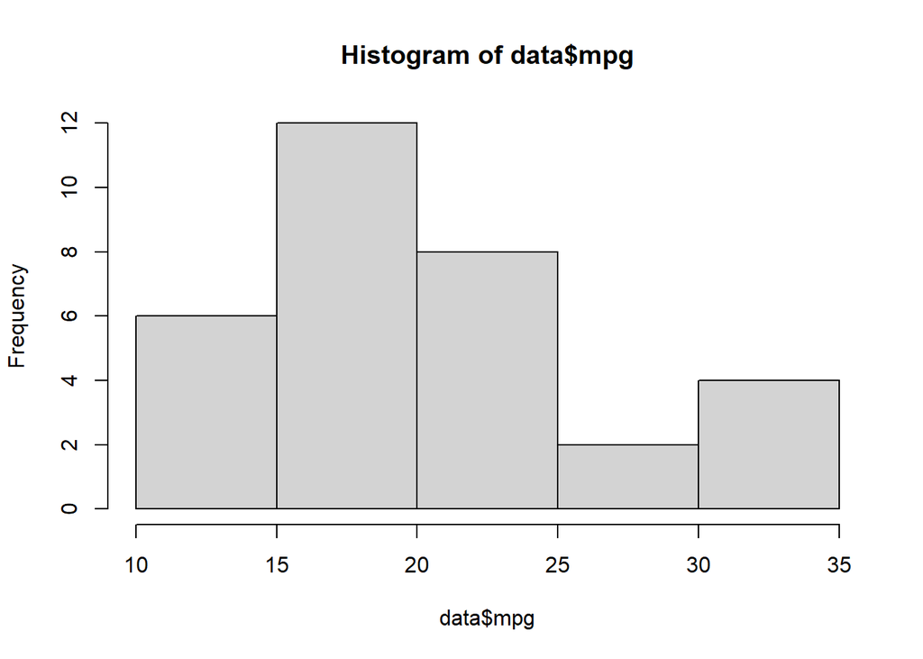

```r
hist(data$mpg)
```

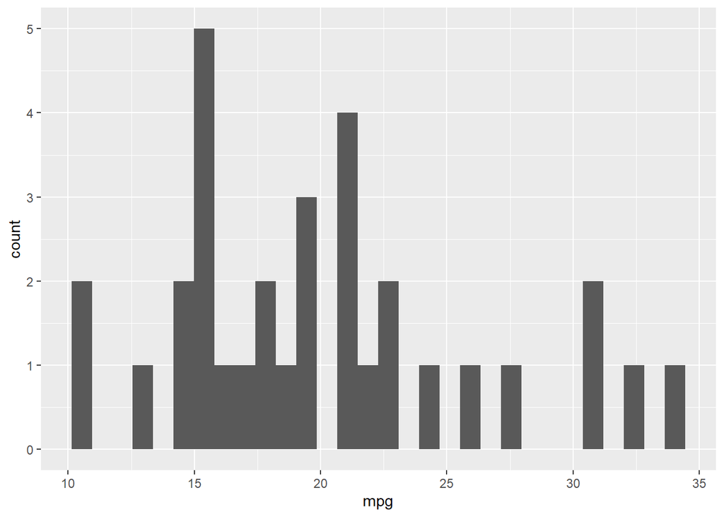

```r
ggplot(data, aes(x = mpg)) + geom_histogram()
```

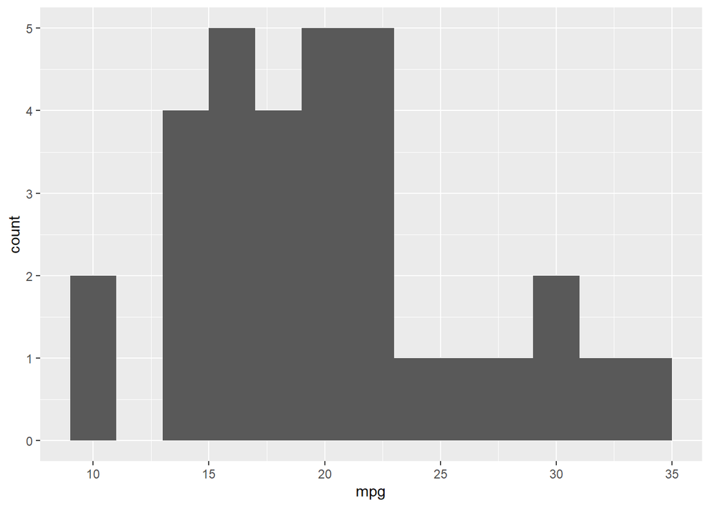

```r
ggplot(data, aes(x = mpg)) + geom_histogram(binwidth = 2)
```

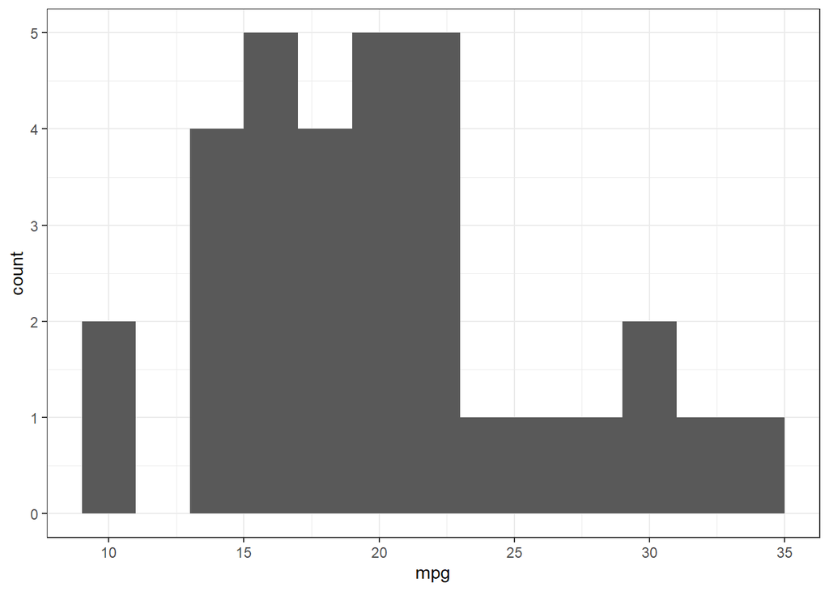

```r
ggplot(data, aes(x = mpg)) + geom_histogram(binwidth = 2) + theme_bw()
```

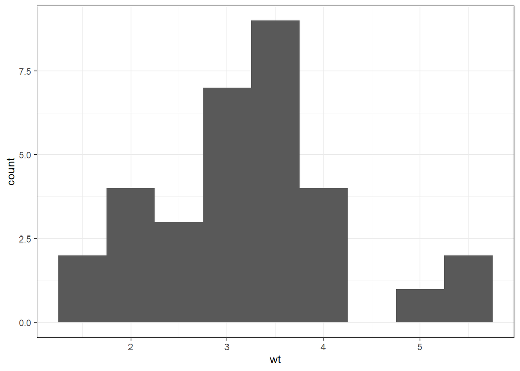

```r
# ??theme_bw

ggplot(data, aes(x = wt)) + geom_histogram(binwidth = 0.5) +
    theme_bw()
```

## Character/Factor (Nominal/Order/Categorical)

```r
table(data$cyl)
```

```
##
##  4  6  8
## 11  7 14
```

```r
prop.table(table(data$cyl))
```

```
##
##       4       6       8
## 0.34375 0.21875 0.43750
```

```r
table(data$am)
```

```
##
##  0  1
## 19 13
```

```r
prop.table(table(data$am))
```

```
##
##       0       1
## 0.59375 0.40625
```

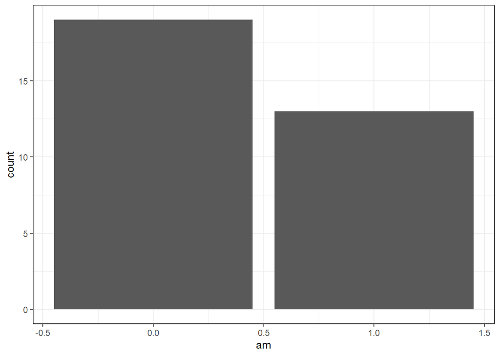

```r
ggplot(data, aes(x = am)) + geom_bar() + theme_bw()
```

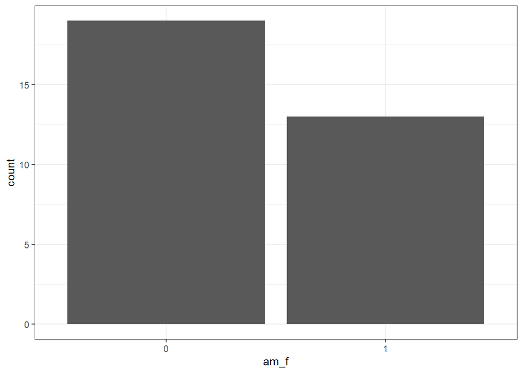

```r
data$am_f <- factor(data$am)


ggplot(data, aes(x = am_f)) + geom_bar() + theme_bw()
```

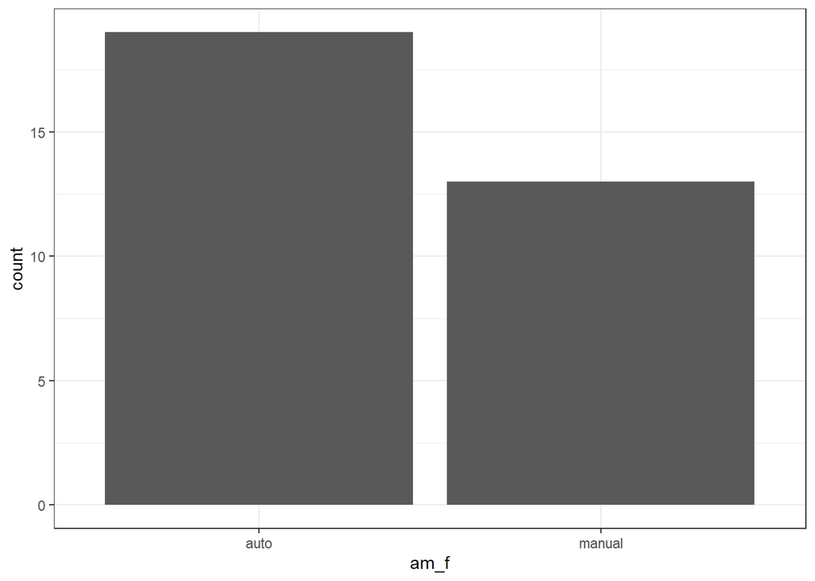

```r
data$am_f <- factor(data$am, labels = c("auto", "manual"))


ggplot(data, aes(x = am_f)) + geom_bar() + theme_bw()
```

## Bivariate

- continuous & discrete

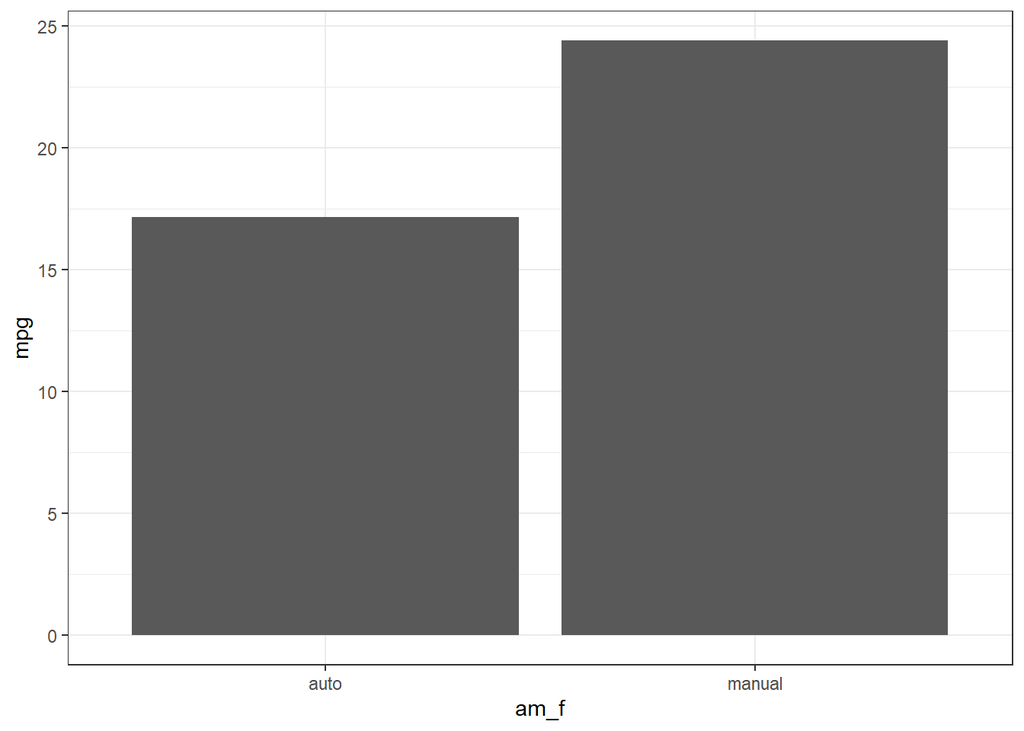

```r
ggplot(data, aes(x = am_f, y = mpg)) + geom_bar(stat = "summary",
    fun = "mean") + theme_bw()
```

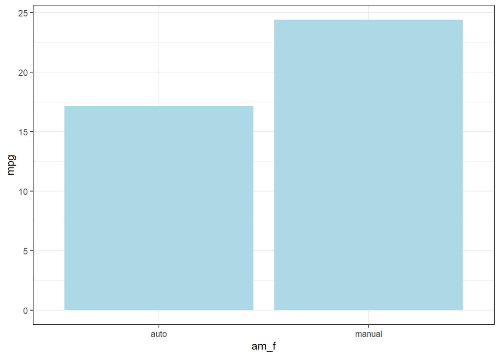

```r
ggplot(data, aes(x = am_f, y = mpg)) + geom_bar(stat = "summary",
    fun = "mean", fill = "lightblue") + theme_bw()
```

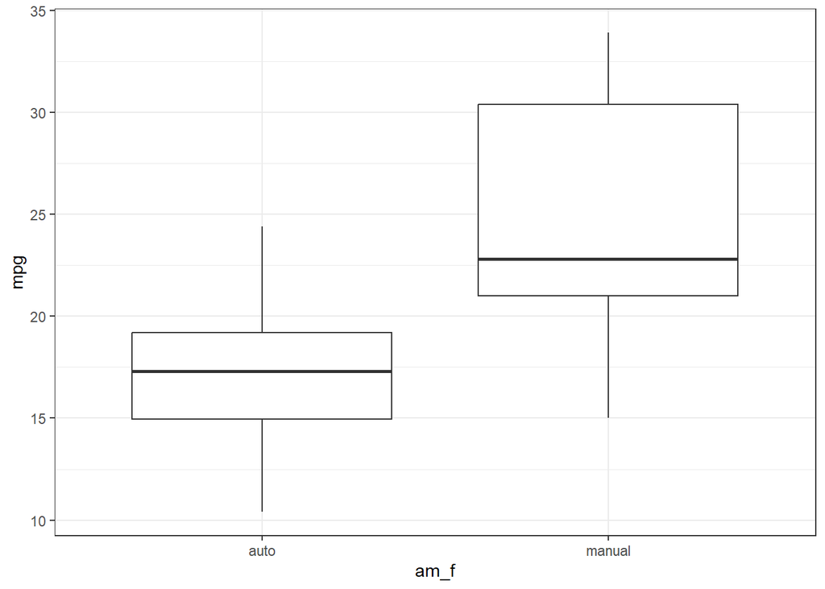

```r
ggplot(data, aes(x = am_f, y = mpg)) + geom_boxplot() + theme_bw()
```

```r
# install.packages('dplyr')
library("dplyr")
data %>%
    group_by(am_f) %>%
    summarize(min = min(mpg), sd = sd(mpg), min = min(mpg), q1 = quantile(mpg,
        0.25), median = median(mpg), q3 = quantile(mpg, 0.75),
        max = max(mpg))
```

| am_f | min | sd | q1 | median | q3 | max |
| --- | --- | --- | --- | --- | --- | --- |
| auto | 10.4 | 3.833966 | 14.95 | 17.3 | 19.2 | 24.4 |
| manual | 15.0 | 6.166504 | 21.00 | 22.8 | 30.4 | 33.9 |

- Continuous & continuous

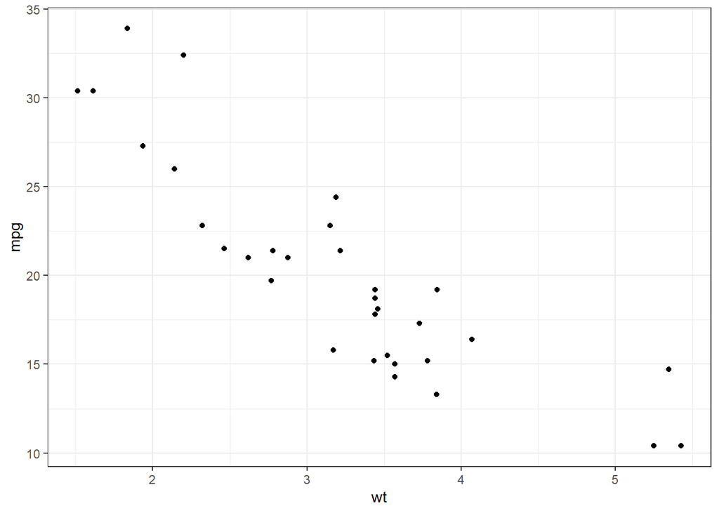

```r
ggplot(data, aes(x = wt, y = mpg)) + geom_point() + theme_bw()
```

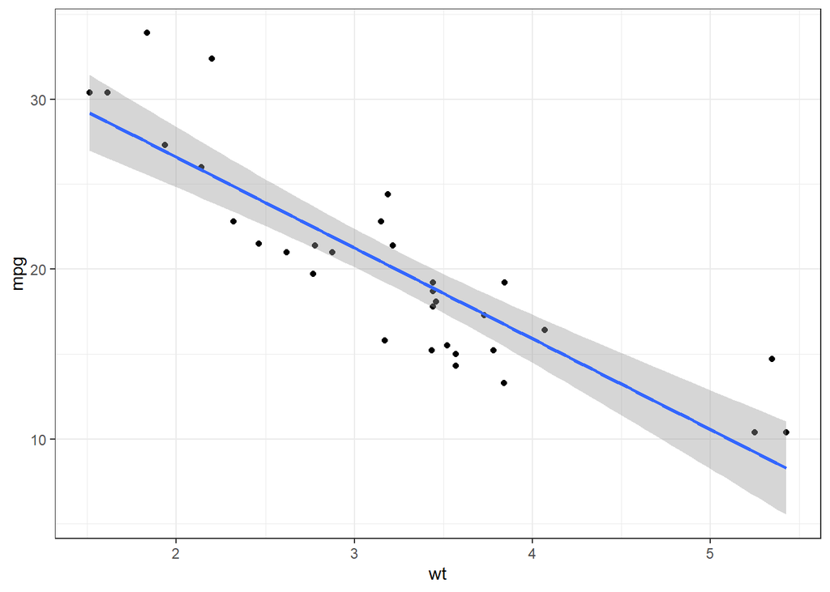

```r
ggplot(data, aes(x = wt, y = mpg)) + geom_point() + geom_smooth(method = "lm") +
    theme_bw()
```

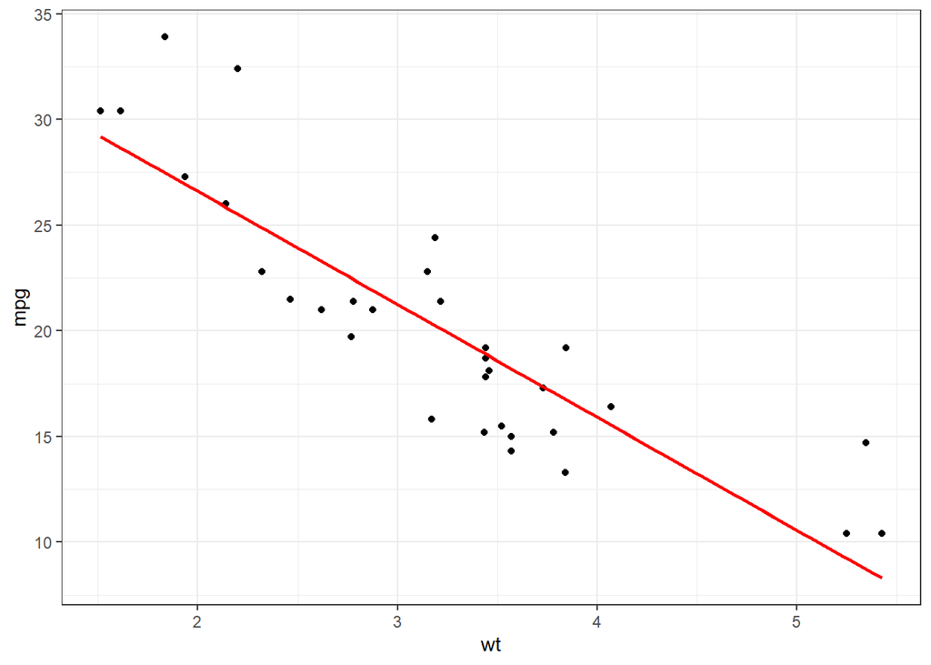

```r
ggplot(data, aes(x = wt, y = mpg)) + geom_point() + geom_smooth(method = "lm",
    col = "red", se = F) + theme_bw()
```

```r
cor(data$wt, data$mpg)
```

```
## [1] -0.8676594
```

```r
cor.test(data$wt, data$mpg)
```

```
##
##  Pearson's product-moment correlation
##
## data:  data$wt and data$mpg
## t = -9.559, df = 30, p-value = 1.294e-10
## alternative hypothesis: true correlation is not equal to 0
## 95 percent confidence interval:
##  -0.9338264 -0.7440872
## sample estimates:
##        cor
## -0.8676594
```

- Discrete & discrete

```r
table(data$cyl, data$am_f)
```

```
##
##     auto manual
##   4    3      8
##   6    4      3
##   8   12      2
```

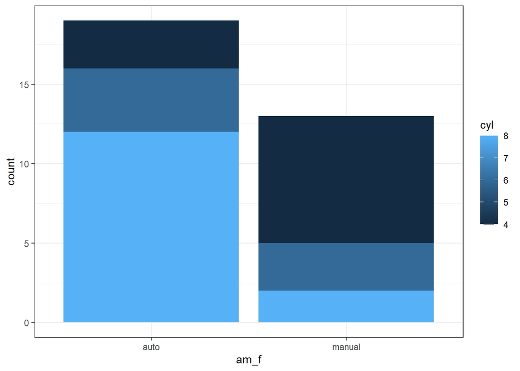

```r
ggplot(data, aes(x = am_f, fill = cyl, group = cyl)) + geom_bar() +
    theme_bw()
```

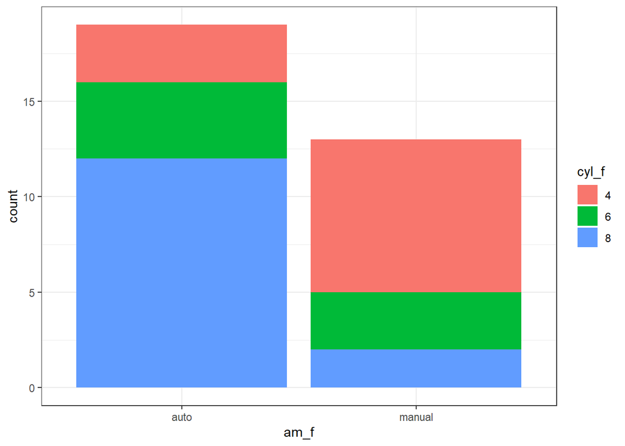

```r
data$cyl_f <- factor(data$cyl)

ggplot(data, aes(x = am_f, fill = cyl_f, group = cyl)) + geom_bar() +
    theme_bw()
```

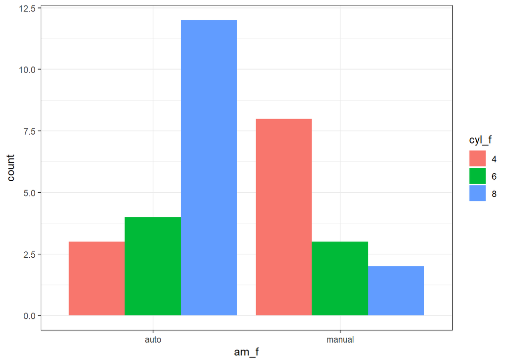

```r
ggplot(data, aes(x = am_f, fill = cyl_f, group = cyl)) + geom_bar(position = "dodge") +
    theme_bw()
```

## Add dimension

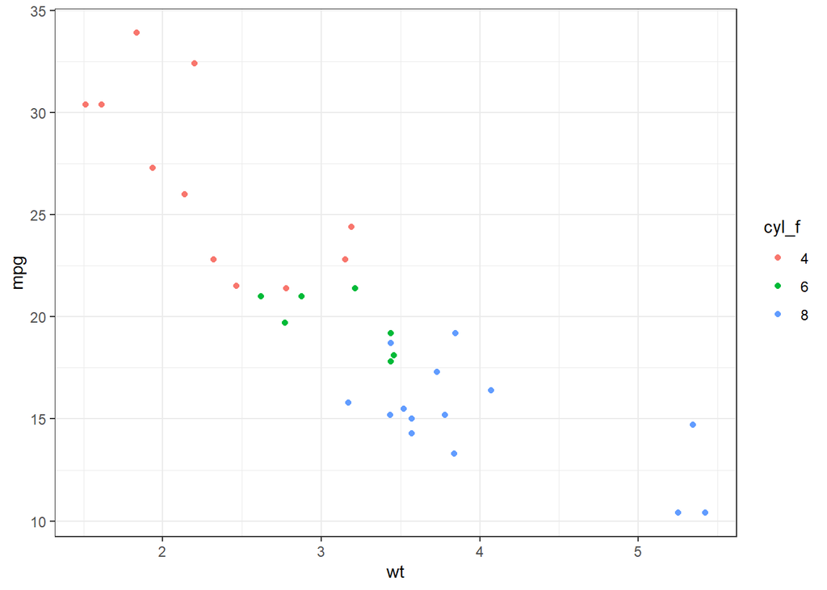

```r
ggplot(data, aes(x = wt, y = mpg, col = cyl_f)) + geom_point() +
    theme_bw()
```

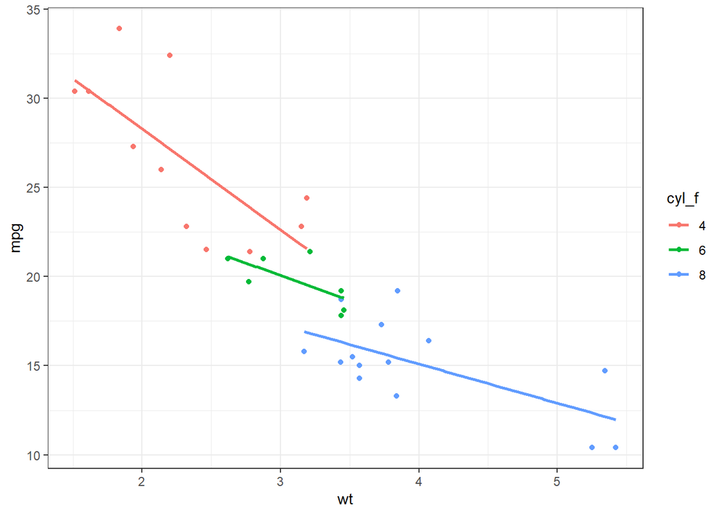

```r
ggplot(data, aes(x = wt, y = mpg, col = cyl_f)) + geom_point() +
    geom_smooth(method = "lm", se = F) + theme_bw()
```

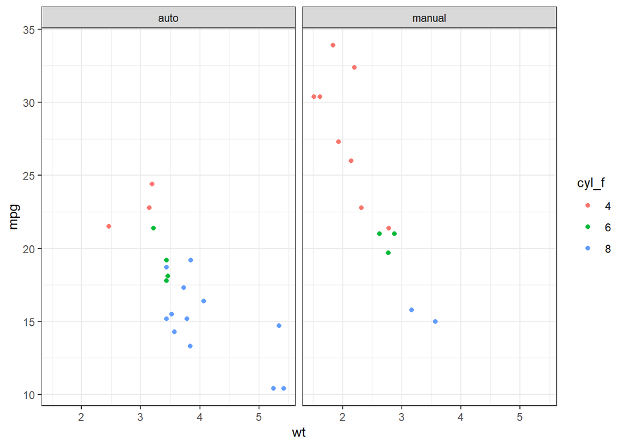

```r
ggplot(data, aes(x = wt, y = mpg, col = cyl_f)) + geom_point() +
    facet_grid(. ~ am_f) + theme_bw()
```

# Linear regression

## Compare means

```r
fit1 <- lm(mpg ~ am_f, data)
summary(fit1)
```

```
##
## Call:
## lm(formula = mpg ~ am_f, data = data)
##
## Residuals:
##     Min      1Q  Median      3Q     Max
## -9.3923 -3.0923 -0.2974  3.2439  9.5077
##
## Coefficients:
##             Estimate Std. Error t value Pr(>|t|)
## (Intercept)   17.147      1.125  15.247 1.13e-15 ***
## am_fmanual     7.245      1.764   4.106 0.000285 ***
## ---
## Signif. codes:  0 '***' 0.001 '**' 0.01 '*' 0.05 '.' 0.1 ' ' 1
##
## Residual standard error: 4.902 on 30 degrees of freedom
## Multiple R-squared:  0.3598, Adjusted R-squared:  0.3385
## F-statistic: 16.86 on 1 and 30 DF,  p-value: 0.000285
```

```r
fit2 <- lm(mpg ~ cyl_f, data)
summary(fit2)
```

```
##
## Call:
## lm(formula = mpg ~ cyl_f, data = data)
##
## Residuals:
##     Min      1Q  Median      3Q     Max
## -5.2636 -1.8357  0.0286  1.3893  7.2364
##
## Coefficients:
##             Estimate Std. Error t value Pr(>|t|)
## (Intercept)  26.6636     0.9718  27.437  < 2e-16 ***
## cyl_f6       -6.9208     1.5583  -4.441 0.000119 ***
## cyl_f8      -11.5636     1.2986  -8.905 8.57e-10 ***
## ---
## Signif. codes:  0 '***' 0.001 '**' 0.01 '*' 0.05 '.' 0.1 ' ' 1
##
## Residual standard error: 3.223 on 29 degrees of freedom
## Multiple R-squared:  0.7325, Adjusted R-squared:  0.714
## F-statistic:  39.7 on 2 and 29 DF,  p-value: 4.979e-09
```

## Simple linear regression

```r
fit3 <- lm(mpg ~ wt, data)
summary(fit3)
```

```
##
## Call:
## lm(formula = mpg ~ wt, data = data)
##
## Residuals:
##     Min      1Q  Median      3Q     Max
## -4.5432 -2.3647 -0.1252  1.4096  6.8727
##
## Coefficients:
##             Estimate Std. Error t value Pr(>|t|)
## (Intercept)  37.2851     1.8776  19.858  < 2e-16 ***
## wt           -5.3445     0.5591  -9.559 1.29e-10 ***
## ---
## Signif. codes:  0 '***' 0.001 '**' 0.01 '*' 0.05 '.' 0.1 ' ' 1
##
## Residual standard error: 3.046 on 30 degrees of freedom
## Multiple R-squared:  0.7528, Adjusted R-squared:  0.7446
## F-statistic: 91.38 on 1 and 30 DF,  p-value: 1.294e-10
```

## Multiple linear regression

```r
fit4 <- lm(mpg ~ wt + cyl_f + am_f, data)
summary(fit4)
```

```
##
## Call:
## lm(formula = mpg ~ wt + cyl_f + am_f, data = data)
##
## Residuals:
##     Min      1Q  Median      3Q     Max
## -4.4898 -1.3116 -0.5039  1.4162  5.7758
##
## Coefficients:
##             Estimate Std. Error t value Pr(>|t|)
## (Intercept)  33.7536     2.8135  11.997  2.5e-12 ***
## wt           -3.1496     0.9080  -3.469  0.00177 **
## cyl_f6       -4.2573     1.4112  -3.017  0.00551 **
## cyl_f8       -6.0791     1.6837  -3.611  0.00123 **
## am_fmanual    0.1501     1.3002   0.115  0.90895
## ---
## Signif. codes:  0 '***' 0.001 '**' 0.01 '*' 0.05 '.' 0.1 ' ' 1
##
## Residual standard error: 2.603 on 27 degrees of freedom
## Multiple R-squared:  0.8375, Adjusted R-squared:  0.8134
## F-statistic: 34.79 on 4 and 27 DF,  p-value: 2.73e-10
```

```r
fit5 <- lm(mpg ~ wt + cyl_f, data)
summary(fit5)
```

```
##
## Call:
## lm(formula = mpg ~ wt + cyl_f, data = data)
##
## Residuals:
##     Min      1Q  Median      3Q     Max
## -4.5890 -1.2357 -0.5159  1.3845  5.7915
##
## Coefficients:
##             Estimate Std. Error t value Pr(>|t|)
## (Intercept)  33.9908     1.8878  18.006  < 2e-16 ***
## wt           -3.2056     0.7539  -4.252 0.000213 ***
## cyl_f6       -4.2556     1.3861  -3.070 0.004718 **
## cyl_f8       -6.0709     1.6523  -3.674 0.000999 ***
## ---
## Signif. codes:  0 '***' 0.001 '**' 0.01 '*' 0.05 '.' 0.1 ' ' 1
##
## Residual standard error: 2.557 on 28 degrees of freedom
## Multiple R-squared:  0.8374, Adjusted R-squared:   0.82
## F-statistic: 48.08 on 3 and 28 DF,  p-value: 3.594e-11
```

```r
AIC(fit4)
```

```
## [1] 158.6065
```

```r
AIC(fit5)
```

```
## [1] 156.6223
```

```r
anova(fit4, fit5)
```

|  | Res.Df | RSS | Df | Sum of Sq | F | Pr(>F) |
| --- | --- | --- | --- | --- | --- | --- |
| 1 | 27 | 182.9683 | NA | NA | NA | NA |
| 2 | 28 | 183.0586 | -1 | -0.09031416 | 0.01332735 | 0.9089474 |

```r
anova(fit4, fit3)
```

|  | Res.Df | RSS | Df | Sum of Sq | F | Pr(>F) |
| --- | --- | --- | --- | --- | --- | --- |
| 1 | 27 | 182.9683 | NA | NA | NA | NA |
| 2 | 30 | 278.3219 | -3 | -95.3536 | 4.690333 | 0.009201561 |

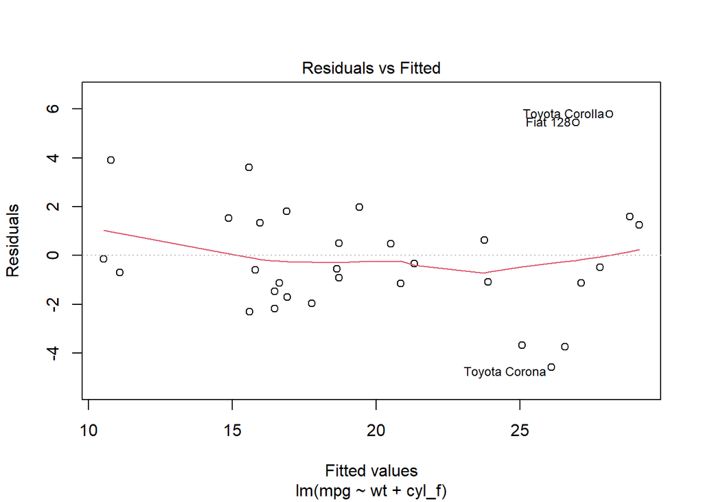

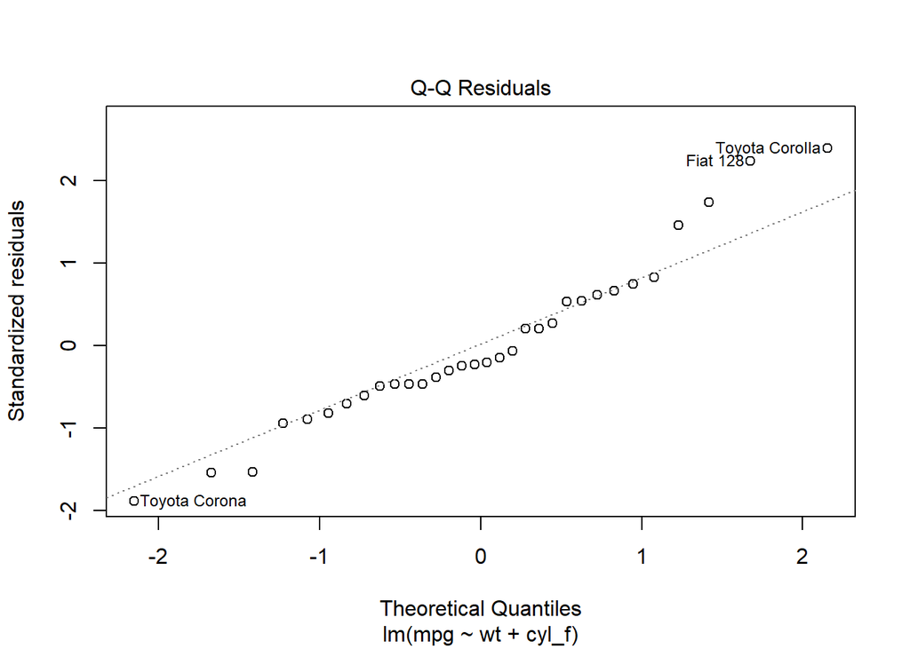

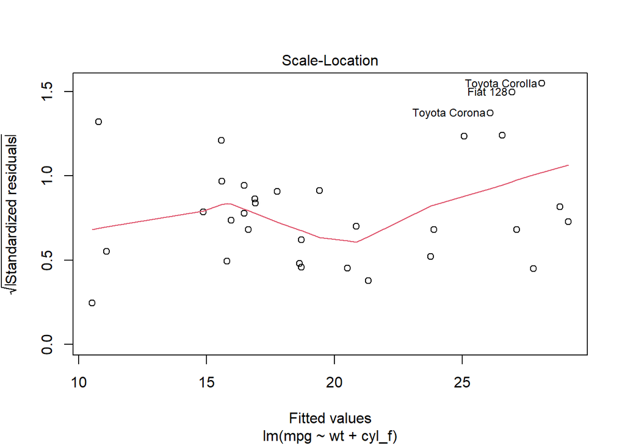

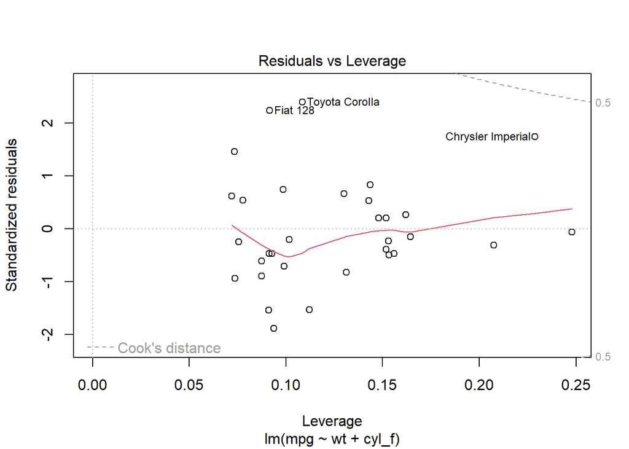

```r
plot(fit5)
```